# BT1101 Descriptive + Predictive Analytics

Ryan Tan Yan Tong

2022-11-18

### Code Cheatsheet

| Code |  |
| --- | --- |
| mutate | adds new variables + Preserve existing variables |
| transmute | adds new variables + Drops existing variables |

## Descriptive Analytics / Data Visualisation

### Kable

```r
# Variables to change
# CR -> dataset
# housingFreq -> May or may not be changed (NOT critical)
# caption -> Heading for pie chart
# col.names -> Column names
housingFreq <- CR %>% count(Housing)
kable(housingFreq, caption = "Housing",
                   col.names = c("House Ownership Status", "Number of Bank Customers"))
```

Housing

| House Ownership Status | Number of Bank Customers |
| --- | --- |
| Other | 52 |
| Own | 292 |
| Rent | 81 |

### Pie Chart

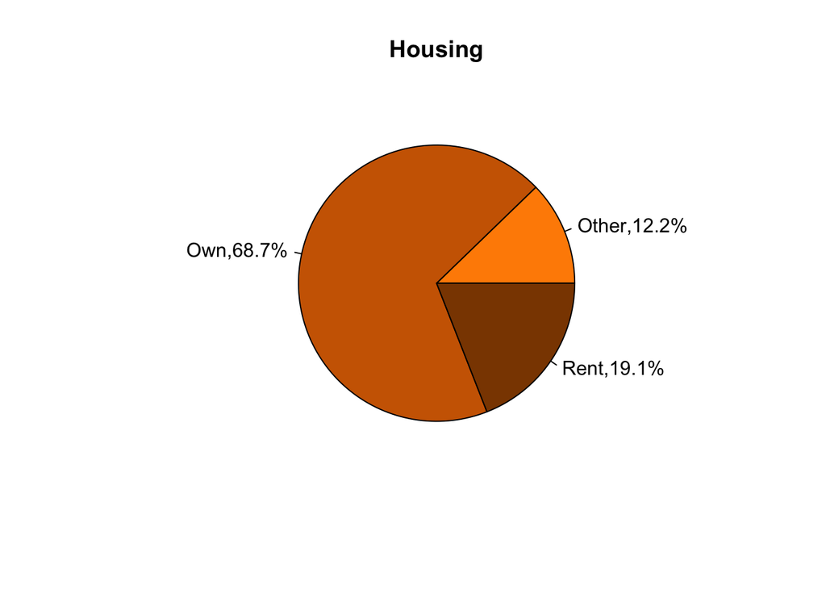

```r
# Variables to Change:
# CR -> dataset
# housingFreq -> May or may not be changed (NOT critical)
# main -> Heading for pie chart
housingFreq <- CR %>% count(Housing)

pie_perc <- 100 * round(housingFreq$n/sum(housingFreq$n), 3)
label <- paste(housingFreq$Housing,
               ",",
               pie_perc,
               "%",
               sep = "")
pie(housingFreq$n,
     labels = label,
     col = c("darkorange", "darkorange3", "darkorange4"),
     main = "Housing")
```

### Bar Chart

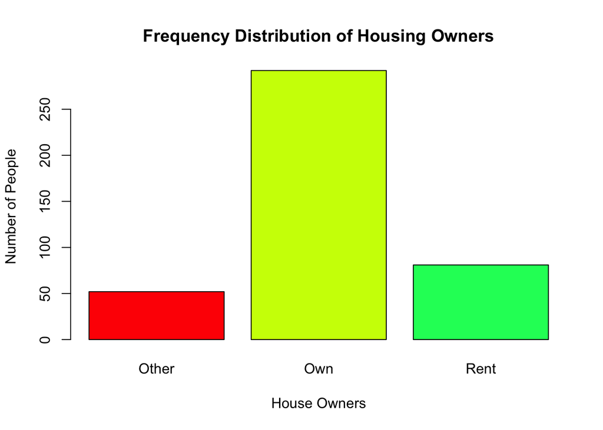

```r
# Variables to change:
# CR -> dataframe
# housingFreq -> variable name (NOT critical)
# Housing -> Name of variable you're counting
# labels
housingFreq <- CR %>% count(Housing)
barplot(housingFreq$n,
        names.arg = housingFreq$Housing,
        col = rainbow(5),
        main = "Frequency Distribution of Housing Owners",
        xlab = "House Owners",
        ylab = "Number of People")
```

### Grouped Bar Chart

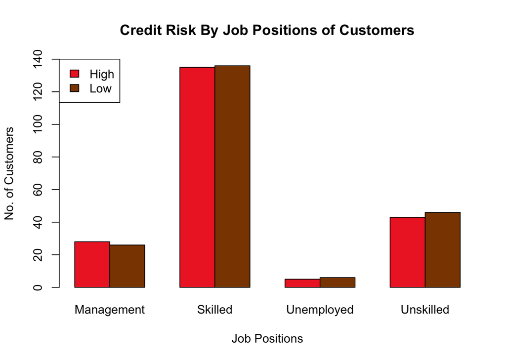

```r
# What is Beside : Credit Risk

# Variables to change:
# Job -> Columns of the bar chart
# Credit Risk -> Groups of bars
# labels
# frequency distribution of (x) for (y) -> group_by(x) %>% count(y)

# Get Credit Risk grouped by Jobs
creditByJob <- CR %>% group_by(Job) %>% count(`Credit Risk`)
# Key is the group, value is count variable
creditByJob_spread <- creditByJob %>% spread(key = Job, value = n)
# kable(creditByJob_spread, caption = "Pivot table for Credit Risk and Job")
barplot(as.matrix(creditByJob_spread[,2:5]), # So that the column names are not used
        beside = TRUE,
        col = c("firebrick2", "darkorange4"),
        ylim = c(0, 140),
        main = "Credit Risk By Job Positions of Customers",
        ylab = "No. of Customers",
        xlab = "Job Positions")
legend("topleft",
       fill = c("firebrick2", "darkorange4"),
       legend = creditByJob_spread$`Credit Risk`)
```

### Histogram

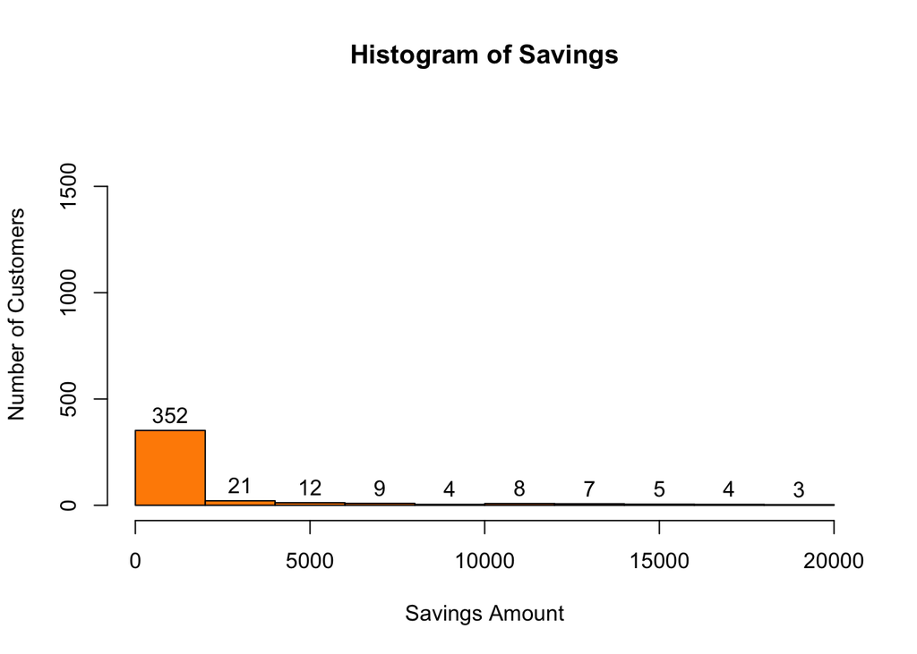

```r
# Variables to change:
# EVERYTHING
# CR -> dataset
# savings -> Variable name
# main / xlab / ylab / col / ylim -> labels
savings <- hist(CR$Savings,
                main = "Histogram of Savings",
                xlab = "Savings Amount",
                ylab = "Number of Customers",
                col = "darkorange",
                ylim = c(0, 1800),
                labels = TRUE)
```

### Histogram Table

```r
# Variables to change:
# CR$Savings -> variable
# savings -> histogram variable
# savingsCut (NOT critical)
# caption -> Label
savingsCut <- cut(CR$Savings,
                  savings$breaks,
                  include.lowest = TRUE)
savingsTable <- table(savingsCut)
kable(savingsTable,
      caption = "Frequency distribution by Savings")
```

Frequency distribution by Savings

| savingsCut | Freq |
| --- | --- |
| [0,2e+03] | 352 |
| (2e+03,4e+03] | 21 |
| (4e+03,6e+03] | 12 |
| (6e+03,8e+03] | 9 |
| (8e+03,1e+04] | 4 |
| (1e+04,1.2e+04] | 8 |
| (1.2e+04,1.4e+04] | 7 |
| (1.4e+04,1.6e+04] | 5 |
| (1.6e+04,1.8e+04] | 4 |
| (1.8e+04,2e+04] | 3 |

### Density Plot

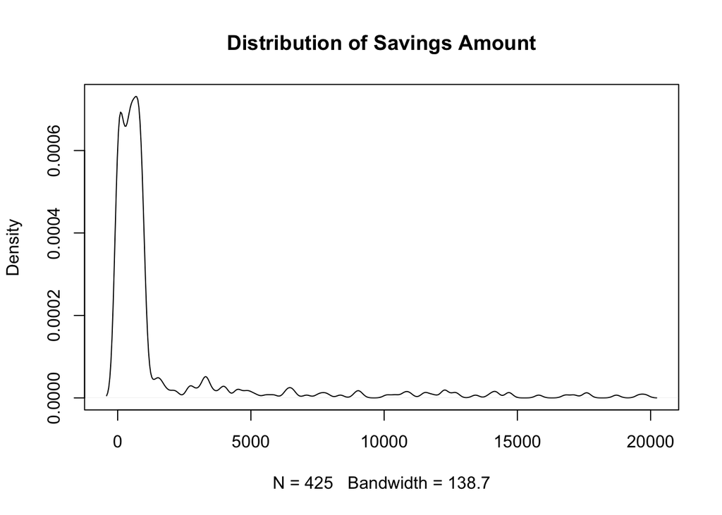

```r
options(scipen = 999)
plot(density(CR$Savings),
     main = "Distribution of Savings Amount")
```

### Commands for graphs to help

| Commands for graphs |  |
| --- | --- |
| horiz = TRUE | Vertical Bars -> Horizontal Bars |
| cex.names = 0.55 | Scale font size of axis labels to 0.55 |
| cex.axis = 0.55 | Scale numeric labels of axes to 0.55 |
| las = 1 | Numeric labels on y-axis orientated to normal way |
| legend.text = unlist(randSpread[, 2:4]) | Add legend labels for grouped bar chart |
| legend(“topleft”) | Legend on top left |
| legend(…, fill = c(““), legend = labels) | 2 other legend arguments necessary |
| options(scipen = 999) | Increase no. of digits shown |

### Statistics

```r
# Helpful Code
# agegp <- factor(ifelse(SK$age < 30, 1, ifelse(SK$age <= 48, 2, 3)), levels = c(1, 2, 3), ordered = TRUE)
describe(ds_salaries$salary)[,c("n","mean","sd","median","skew","kurtosis")]
```

```
##      n     mean      sd median  skew kurtosis
## X1 607 324000.1 1544357 115000 13.98   244.57
```

```r
# Skewness:
#   -ve: Left-skewed
#   |CS|>1: High degree of skewness
#   1>|CS|>0.5: Moderate degree of skewness
#   0.5>|CS|: Relative symmetry
# Kurtosis:
#   CK > 3: Somewhat peaked, Low degree of dispersion
#   CK < 3: Somewhat flat, High degree of dispersion
quantile(ds_salaries$salary, c(.25, .5, .75,1))
```

```
##      25%      50%      75%     100%
##    70000   115000   165000 30400000
```

### Pareto Analysis

```r
# Variables to change :
# ds_salaries -> dataset
# salary_in_usd -> variable for analysis
# (cum_)salary_frac (NOT critical)
# 0.8 -> Whatever percentage is required
cum_salary <- ds_salaries %>% transmute(salary_frac = salary_in_usd / sum(salary_in_usd)) %>%
                              arrange(desc(salary_frac)) %>%
                              mutate(cum_salary_frac = cumsum(salary_frac))
# Number that contributes to 80%
cumNum <- which(cum_salary$cum_salary_frac>0.8)[1]
cumPerc <- cumNum / nrow(cum_salary)
cumNum
```

```
## [1] 352
```

```r
cumPerc
```

```
## [1] 0.5799012
```

```r
# Plot graph if required
# plot(cum_salary$cum_salary_frac, type = "n")
# lines(cum_salary$cum_salary_frac)
```

### Correlation Matrix

- ___ has a (strong), (positive), (linear) correlation with ___.

```r
cor(mtcars)
```

```
##             mpg        cyl       disp         hp        drat         wt
## mpg   1.0000000 -0.8521620 -0.8475514 -0.7761684  0.68117191 -0.8676594
## cyl  -0.8521620  1.0000000  0.9020329  0.8324475 -0.69993811  0.7824958
## disp -0.8475514  0.9020329  1.0000000  0.7909486 -0.71021393  0.8879799
## hp   -0.7761684  0.8324475  0.7909486  1.0000000 -0.44875912  0.6587479
## drat  0.6811719 -0.6999381 -0.7102139 -0.4487591  1.00000000 -0.7124406
## wt   -0.8676594  0.7824958  0.8879799  0.6587479 -0.71244065  1.0000000
## qsec  0.4186840 -0.5912421 -0.4336979 -0.7082234  0.09120476 -0.1747159
## vs    0.6640389 -0.8108118 -0.7104159 -0.7230967  0.44027846 -0.5549157
## am    0.5998324 -0.5226070 -0.5912270 -0.2432043  0.71271113 -0.6924953
## gear  0.4802848 -0.4926866 -0.5555692 -0.1257043  0.69961013 -0.5832870
## carb -0.5509251  0.5269883  0.3949769  0.7498125 -0.09078980  0.4276059
##             qsec         vs          am       gear        carb
## mpg   0.41868403  0.6640389  0.59983243  0.4802848 -0.55092507
## cyl  -0.59124207 -0.8108118 -0.52260705 -0.4926866  0.52698829
## disp -0.43369788 -0.7104159 -0.59122704 -0.5555692  0.39497686
## hp   -0.70822339 -0.7230967 -0.24320426 -0.1257043  0.74981247
## drat  0.09120476  0.4402785  0.71271113  0.6996101 -0.09078980
## wt   -0.17471588 -0.5549157 -0.69249526 -0.5832870  0.42760594
## qsec  1.00000000  0.7445354 -0.22986086 -0.2126822 -0.65624923
## vs    0.74453544  1.0000000  0.16834512  0.2060233 -0.56960714
## am   -0.22986086  0.1683451  1.00000000  0.7940588  0.05753435
## gear -0.21268223  0.2060233  0.79405876  1.0000000  0.27407284
## carb -0.65624923 -0.5696071  0.05753435  0.2740728  1.00000000
```

```r
corr.test(ds_salaries$salary, as.numeric(ds_salaries$remote_ratio))
```

```
## Call:corr.test(x = ds_salaries$salary, y = as.numeric(ds_salaries$remote_ratio))
## Correlation matrix
## [1] -0.01
## Sample Size
## [1] 607
## These are the unadjusted probability values.
##   The probability values  adjusted for multiple tests are in the p.adj object.
## [1] 0.72
##
##  To see confidence intervals of the correlations, print with the short=FALSE option
```

## Predictive Analytics

Refer to flowchart:

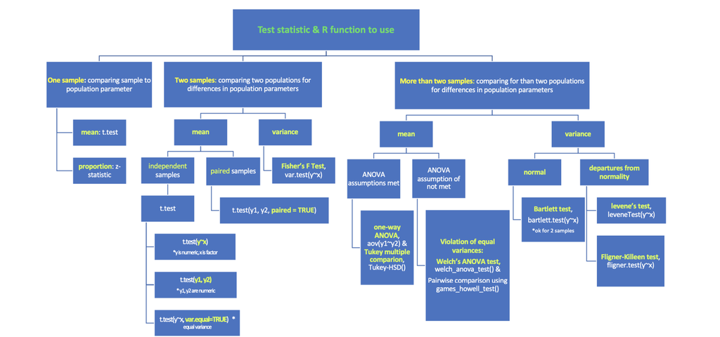

### Intervals

#### Outlier Analysis

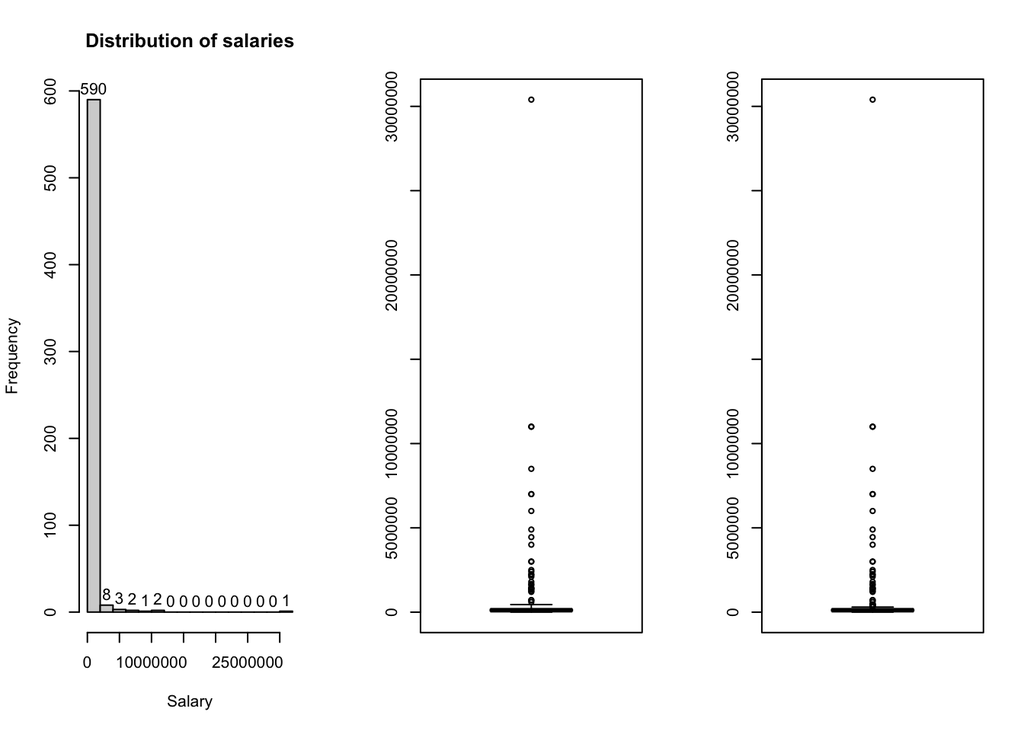

```r
par(mfrow=c(1,3)) #this function makes plots below be displayed together
hist(ds_salaries$salary,
     labels = TRUE,
     #xlim = c(20000,120000),
     #ylim = c(0,60),
     main = "Distribution of salaries",
     xlab = "Salary")
extreme <- boxplot(ds_salaries$salary, range = 3)
mild <- boxplot(ds_salaries$salary, range = 1.5)
```

```r
extreme$out
```

```
##  [1] 11000000  3000000  4450000   720000  1450000  2200000 11000000  2250000
##  [9]   700000  3000000  7000000  8500000 30400000  1672000  1799997  4000000
## [17]  2500000  1200000  1600000  1335000   600000  2100000  1250000  4900000
## [25]  7000000  6000000  1400000  2400000  1400000
```

```r
mild$out
```

```
##  [1] 11000000  3000000  4450000   423000   450000   325000   720000   450000
##  [9]   450000   412000   400000  1450000  2200000   450000 11000000  2250000
## [17]   700000  3000000  7000000  8500000   423000 30400000   420000  1672000
## [25]  1799997  4000000   435000  2500000   416000  1200000  1600000  1335000
## [33]   600000  2100000  1250000  4900000  7000000  6000000  1400000  2400000
## [41]  1400000   324000   380000   405000
```

#### Normality Checks

- Quick link to ANOVA
- Just one of the charts is sufficient
- An ANOVA test is to be conducted to determine if there is any difference in mean (income).
  - Firstly, the normality of () was plotted out using a (histogram) and a Shapiro-Wilks test was conducted on the ().
  - With all the () showing a W statistic value greater than 0.9, as well as each histogram looking relatively normal, it can be concluded that the () is normally distributed.
  - When conducting the Fligner-Killeen test, it can be seen with a p-value of (), that there is (sufficient evidence) to suggest that the variance between the () is different.
  - From the Welch ANOVA test, it can be seen with a p-value of () that there is (sufficient evidence to reject the null hypothesis in favour of the alternate hypothesis) and conclude that ___
  - To identify this, a Games-Howell post-hoc test was conducted. From the results, it can be seen that the with a p-value of () for the pairwise test between () and (), there is (insufficient evidence to suggest) that (mean ___) is different.

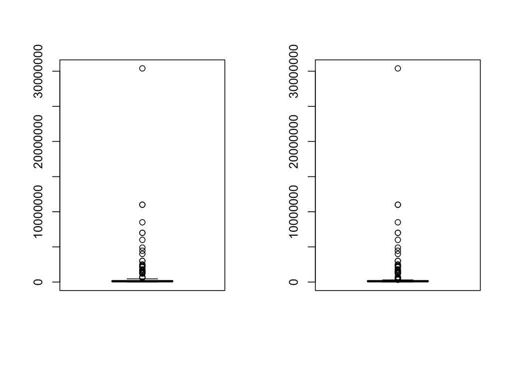

```r
# Check for outliers first
par(mfrow=c(1,2))
extreme <- boxplot(ds_salaries$salary, range = 3)
mild <- boxplot(ds_salaries$salary, range = 1.5)
```

```r
extreme$out
```

```
##  [1] 11000000  3000000  4450000   720000  1450000  2200000 11000000  2250000
##  [9]   700000  3000000  7000000  8500000 30400000  1672000  1799997  4000000
## [17]  2500000  1200000  1600000  1335000   600000  2100000  1250000  4900000
## [25]  7000000  6000000  1400000  2400000  1400000
```

```r
mild$out
```

```
##  [1] 11000000  3000000  4450000   423000   450000   325000   720000   450000
##  [9]   450000   412000   400000  1450000  2200000   450000 11000000  2250000
## [17]   700000  3000000  7000000  8500000   423000 30400000   420000  1672000
## [25]  1799997  4000000   435000  2500000   416000  1200000  1600000  1335000
## [33]   600000  2100000  1250000  4900000  7000000  6000000  1400000  2400000
## [41]  1400000   324000   380000   405000
```

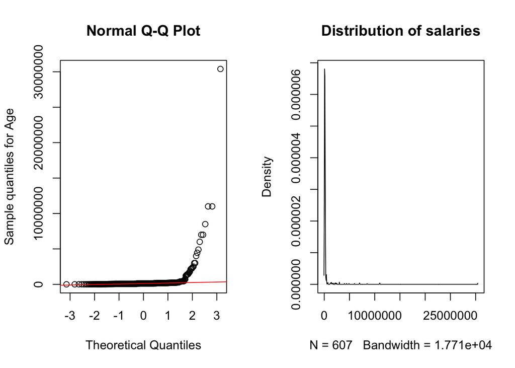

```r
# Check for normality with charts
qqnorm(ds_salaries$salary, ylab = "Sample quantiles for Age")
qqline(ds_salaries$salary, col = 'red')

plot(density(ds_salaries$salary),
     main = "Distribution of salaries")
```

```r
# Shapiro-Wilk Test
shapiro.test(ds_salaries$salary)
```

```
##
##  Shapiro-Wilk normality test
##
## data:  ds_salaries$salary
## W = 0.139, p-value < 0.00000000000000022
```

#### Prediction Interval

- NOTE: PI formula is different from CI formula

```
##
##     lambda      W        Shapiro.p.value
## 394 -0.175 0.9226 0.00000000000000004137
##
## if (lambda >  0){TRANS = x ^ lambda}
## if (lambda == 0){TRANS = log(x)}
## if (lambda <  0){TRANS = -1 * x ^ lambda}
```

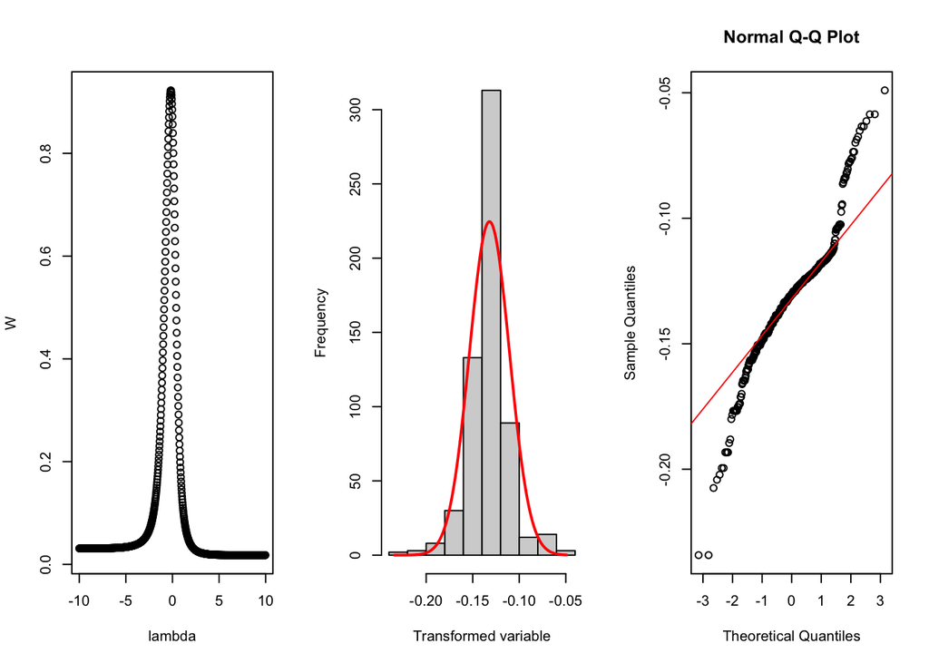

```r
# Variables to change :
# ds_salaries -> dataset
# ds_salaries$salary

# Transform to normal distribution
par(mfrow=c(1,3))
normSal <- transformTukey(ds_salaries$salary, plotit = TRUE)
```

```r
# Calculate 95% Prediction Interval
m_salary  <- mean(normSal)
sd_salary <- sd(normSal)

PI95normLow <- m_salary + (qt(0.025, df = (nrow(ds_salaries) - 1)) * sd_salary * sqrt(1+ 1/nrow(ds_salaries)))
PI95normUp  <- m_salary + (qt(0.975, df = (nrow(ds_salaries) - 1)) * sd_salary * sqrt(1+ 1/nrow(ds_salaries)))

PI95Low <- (-PI95normLow)^ (1 / -0.175) # Formatting is required cos negative numbers cannot be raised to fractions
PI95Up  <- (-PI95normUp) ^ (1 / -0.175)

print(cbind(PI95Low, PI95Up), digits = 4)
```

```
##      PI95Low PI95Up
## [1,]   21609 970032
```

#### Confidence Interval / One sample Hypo Testing

##### z-value (Known population s.t.d.)

```r
m_salary  <- mean(ds_salaries$salary)
sd_salary  <- sd(ds_salaries$salary)

CI95Low <- m_salary + qnorm(0.025) * sd_salary/sqrt(nrow(ds_salaries))
CI95Up  <- m_salary + qnorm(0.975) * sd_salary/sqrt(nrow(ds_salaries))
print(cbind(CI95Low, CI95Up), digits = 4)
```

```
##      CI95Low CI95Up
## [1,]  201143 446858
```

##### t-value (unknown population s.t.d.)

```r
m_salary  <- mean(ds_salaries$salary)
sd_salary  <- sd(ds_salaries$salary)

CI95Low <- m_salary + qt(0.025, df = nrow(ds_salaries) - 1) * sd_salary/sqrt(nrow(ds_salaries))
CI95Up  <- m_salary + qt(0.975, df = nrow(ds_salaries) - 1) * sd_salary/sqrt(nrow(ds_salaries))
print(cbind(CI95Low, CI95Up), digits = 4)
```

```
##      CI95Low CI95Up
## [1,]  200897 447103
```

##### proportion interval

```r
highSal <- nrow(ds_salaries %>% filter(salary > 100000))
propSal <- highSal / nrow(ds_salaries)

propSalLow <- propSal + (qnorm(0.025)*sqrt(propSal*(1-propSal)/nrow(ds_salaries)))
propSalUp  <- propSal + (qnorm(0.975)*sqrt(propSal*(1-propSal)/nrow(ds_salaries)))
print(cbind(propSalLow, propSalUp), digits = 4)
```

```
##      propSalLow propSalUp
## [1,]     0.5256    0.6045
```

##### proportion hypo testing

```r
# Assume Proportion is that,
#   then proportion of current sample -> how unlikely to get
# This example tests for proportion of population = 0.1
highSal <- nrow(ds_salaries %>% filter(salary > 100000))
propSal <- highSal / nrow(ds_salaries)
z <- (propSal - 0.1) / sqrt(0.1 * (1 - 0.1) / nrow(ds_salaries))
z
```

```
## [1] 38.19401
```

```r
qnorm(0.05)
```

```
## [1] -1.644854
```

Since proportion of sample is >> 0.1, 2 conclusions 1.) z-statistic provides evidence that proportion > 0.1 (qnorm(0.95)) 2.) insufficient evidence to reject H0 that proportion is at least 10% (qnorm(0.05))

#### Hypothesis Testing

##### Two-sample t-test

```r
# 2 separate variables
t.test(trees$Girth, trees$Volume, alternative = "less")
```

```
##
##  Welch Two Sample t-test
##
## data:  trees$Girth and trees$Volume
## t = -5.6303, df = 32.184, p-value = 0.000001557
## alternative hypothesis: true difference in means is less than 0
## 95 percent confidence interval:
##       -Inf -11.83222
## sample estimates:
## mean of x mean of y
##  13.24839  30.17097
```

```r
# Filter so that dataframe has just 2 factor variables for that column
ds_salaries_2factor <- ds_salaries %>% filter(employment_type %in% c("FT", "PT"))
t.test(salary~employment_type, data = ds_salaries_2factor)
```

```
##
##  Welch Two Sample t-test
##
## data:  salary by employment_type
## t = 3.2544, df = 114.13, p-value = 0.001496
## alternative hypothesis: true difference in means between group FT and group PT is not equal to 0
## 95 percent confidence interval:
##   96119.31 395177.93
## sample estimates:
## mean in group FT mean in group PT
##         331124.6          85476.0
```

- The t-statistic is 3.2544 with p-value of 0.001496. Since p-value<0.05, we can conclude that there is a significant difference between the mean salaries of FT and PT.

##### More than 2-sample

- Do normality checks first
- Equal Variance
- Welch-ANOVA

###### Welch-ANOVA

```r
# Check for normality -> As above

# Equal Variance Check
smoke$ageGrp <- factor(ifelse(smoke$age < 30, 1, ifelse(smoke$age <= 48, 2, 3)), levels = c(1, 2, 3), ordered = TRUE)
# Normal Distribution
bartlett.test(cigs~ageGrp, data = smoke)
```

```
##
##  Bartlett test of homogeneity of variances
##
## data:  cigs by ageGrp
## Bartlett's K-squared = 23.397, df = 2, p-value = 0.000008305
```

```r
# Not Normal
fligner.test(cigs~ageGrp, data = smoke)
```

```
##
##  Fligner-Killeen test of homogeneity of variances
##
## data:  cigs by ageGrp
## Fligner-Killeen:med chi-squared = 3.4464, df = 2, p-value = 0.1785
```

```r
# Welch-ANOVA
welch_anova_test(cigs~ageGrp, data = smoke)
```

```
## # A tibble: 1 × 7
##   .y.       n statistic   DFn   DFd     p method
## * <chr> <int>     <dbl> <dbl> <dbl> <dbl> <chr>
## 1 cigs    807      1.94     2  535. 0.145 Welch ANOVA
```

```r
# Welch-anova post-hoc: Games Howell
games_howell_test(cigs~ageGrp, data = smoke)
```

```
## # A tibble: 3 × 8
##   .y.   group1 group2 estimate conf.low conf.high p.adj p.adj.signif
## * <chr> <chr>  <chr>     <dbl>    <dbl>     <dbl> <dbl> <chr>
## 1 cigs  1      2         2.19    -0.600     4.98  0.156 ns
## 2 cigs  1      3         0.161   -2.40      2.72  0.988 ns
## 3 cigs  2      3        -2.03    -4.92      0.857 0.225 ns
```

- Only p-value is important for the fligner test
- Since the p-value for the welch ANOVA test is 0.145 > 0.05, there is insufficient evidence to reject H0

###### ANOVA

```r
aovRes <- aov(cigs~ageGrp, data = smoke)
summary(aovRes)
```

```
##              Df Sum Sq Mean Sq F value Pr(>F)
## ageGrp        2    821   410.7   2.188  0.113
## Residuals   804 150932   187.7
```

```r
TukeyHSD(aovRes)
```

```
##   Tukey multiple comparisons of means
##     95% family-wise confidence level
##
## Fit: aov(formula = cigs ~ ageGrp, data = smoke)
##
## $ageGrp
##           diff        lwr       upr     p adj
## 2-1  2.1911568 -0.5900885 4.9724022 0.1542323
## 3-1  0.1605621 -2.6544501 2.9755744 0.9901602
## 3-2 -2.0305947 -4.7651419 0.7039525 0.1896954
```

### Linear Models

- Y = b0 + b1 * X + e : Need to type out e (error term) as well for full equation
- Marginal Effect
  - For every unit increase increase in (), the () increases / decreases by () on average, holding all other variables constant.
- Significant
  - Since t-value is () with a large magnitude and p-value is () < 0.05, there is enough evidence to support the alternate hypothesis that the coefficient of () is statistically different from zero. This means that () is significantly associated with ().
  - Since t-value is () with a small magnitude and p-value is () > 0.05, there is insufficient evidence to reject the null hypothesis that the coefficient of () is statistically different from zero. This means that () is statistically insignificant and is not significantly associated with ().
- F-test
  - The p-value associated to this coefficient is smaller than 0.05 which shows that this coefficient is significantly different from 0 at a 95% confidence level
  - H0: All slope parameters are zero
  - H1: At least one of the slope paramters is nonzero.

#### Simple LM

```r
options(scipen = 5)
summary(lm(durat~tserved, recid))
```

```
##
## Call:
## lm(formula = durat ~ tserved, data = recid)
##
## Residuals:
##    Min     1Q Median     3Q    Max
## -57.71 -26.79  14.28  19.90  73.24
##
## Coefficients:
##             Estimate Std. Error t value Pr(>|t|)
## (Intercept) 60.23062    0.95526  63.052  < 2e-16 ***
## tserved     -0.25327    0.03362  -7.533 8.74e-14 ***
## ---
## Signif. codes:  0 '***' 0.001 '**' 0.01 '*' 0.05 '.' 0.1 ' ' 1
##
## Residual standard error: 26.79 on 1443 degrees of freedom
## Multiple R-squared:  0.03783,    Adjusted R-squared:  0.03717
## F-statistic: 56.74 on 1 and 1443 DF,  p-value: 8.737e-14
```

#### Multivariate LM

```r
fit_d = lm(durat ~ tserved + drugs + alcohol + priors + workprg, data = recid)
summary(fit_d)
```

```
##
## Call:
## lm(formula = durat ~ tserved + drugs + alcohol + priors + workprg,
##     data = recid)
##
## Residuals:
##    Min     1Q Median     3Q    Max
## -61.13 -26.17  13.81  18.93  75.50
##
## Coefficients:
##             Estimate Std. Error t value Pr(>|t|)
## (Intercept) 62.24434    1.24993  49.798  < 2e-16 ***
## tserved     -0.25630    0.03474  -7.378  2.7e-13 ***
## drugs       -2.36192    1.63400  -1.445 0.148539
## alcohol     -5.59695    1.75927  -3.181 0.001497 **
## priors      -0.90386    0.25443  -3.553 0.000394 ***
## workprg      2.32777    1.43840   1.618 0.105816
## ---
## Signif. codes:  0 '***' 0.001 '**' 0.01 '*' 0.05 '.' 0.1 ' ' 1
##
## Residual standard error: 26.52 on 1439 degrees of freedom
## Multiple R-squared:  0.05958,    Adjusted R-squared:  0.05631
## F-statistic: 18.23 on 5 and 1439 DF,  p-value: < 2.2e-16
```

#### Prediction

```r
fit_f = lm(follow ~ rules + age + tserved + married,  data = recid)
newoffender = data.frame(rules = 0, age = 32*12, tserved = 3*12+7, married = 1)
predict(fit_f, newdata = newoffender)
```

```
##        1
## 74.52686
```

#### Assumptions:

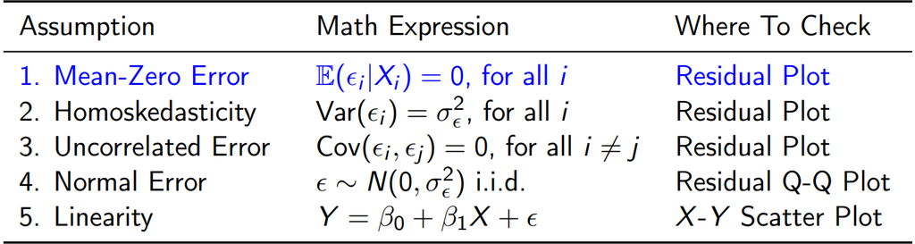

Linear Model Assumptions

##### Linear Relationship

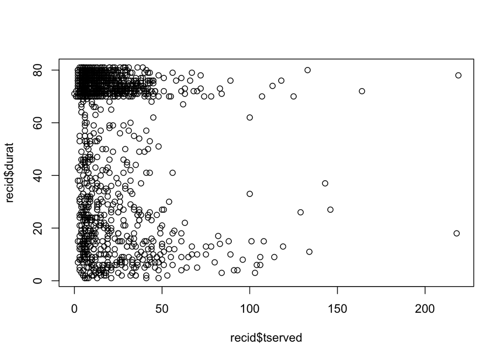

```r
plot(recid$tserved, recid$durat)
```

- Check if the relationship is linear through scatterplot

##### Residual Assumptions

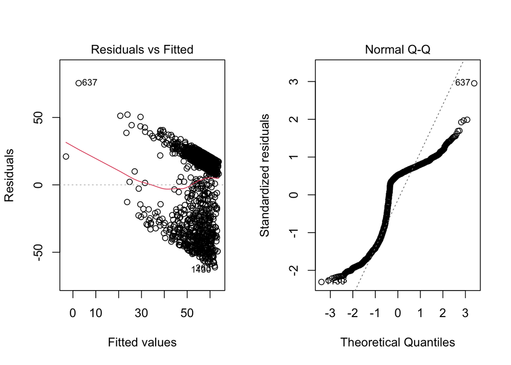

```r
par(mfrow = c(1,2))
plot(fit_d, 1)
plot(fit_d, 2)
```

- From the residual plot, we can see a significant decreasing pattern of residuals when fitted value gets larger.
  - This implies not only autocorrelation but a strong correlation between the residuals and fitted value y^ or implicitly some of independent variables X’s as well.
  - The latter is more sever, violating assumption of mean-zero error.
  - The OLS estimator is not valid, in terms of (1) biased estimate and (2) wrong standard error and invalid inference.
- Residual Q-Q plot also shows that the plot is tilted away from 45 degree line
  - violating the assumption that the error follows a normal distribution
- Note: The failure of mean-zero error is likely due to missing variables, i.e. some key variables that are unobserved (thus left in the error term) to us but correlate with independent variables X’s. More inspection thus is needed to draw a valid conclusion.

#### GLM (Generalised Linear Model)

- Prediction of binary variable (Success / Failure)

```r
logit_s = glm(super ~ rules + age + tserved + married + black,
              data = recid,
              family = binomial)
summary(logit_s)
```

```
##
## Call:
## glm(formula = super ~ rules + age + tserved + married + black,
##     family = binomial, data = recid)
##
## Deviance Residuals:
##     Min       1Q   Median       3Q      Max
## -2.9171  -1.2826   0.7302   0.8673   1.9883
##
## Coefficients:
##               Estimate Std. Error z value Pr(>|z|)
## (Intercept)  1.0144454  0.1965122   5.162 2.44e-07 ***
## rules       -0.2440268  0.0359240  -6.793 1.10e-11 ***
## age         -0.0018470  0.0004914  -3.759 0.000171 ***
## tserved      0.0319665  0.0048895   6.538 6.25e-11 ***
## married      0.5115352  0.1458073   3.508 0.000451 ***
## black        0.1132077  0.1189016   0.952 0.341040
## ---
## Signif. codes:  0 '***' 0.001 '**' 0.01 '*' 0.05 '.' 0.1 ' ' 1
##
## (Dispersion parameter for binomial family taken to be 1)
##
##     Null deviance: 1779.6  on 1444  degrees of freedom
## Residual deviance: 1687.6  on 1439  degrees of freedom
## AIC: 1699.6
##
## Number of Fisher Scoring iterations: 4
```

##### GLM Prediction

- Marginal Effect: A unit increase in () is associated with log-odds of () increasing / decreasing on average, keeping all other variables constant.

```r
newclient = data.frame(rules = 0, age = 46*12, tserved = 3*12+7, married = 1, black = 0)
predict(logit_s,
        type = 'response',
        newdata = newclient)
```

```
##         1
## 0.8677237
```

### Time Series

- Trivial: Addition of time trend variable to linear model
- SMA / EMA

#### SMA

- Predicted values are just the rows (Last row is last predicted value, …)

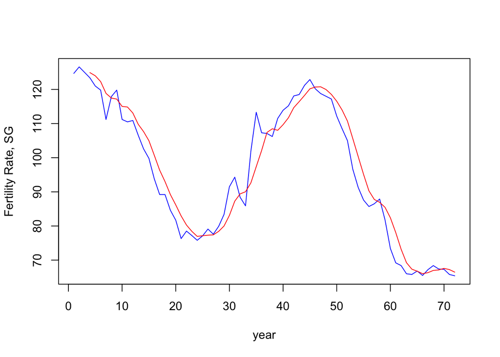

```r
gfrsg <- as.data.frame(fertil)$gfr
gfrsg4 <- TTR::SMA(gfrsg, n = 4)
ts_comb <- cbind(gfrsg, gfrsg4)
ts.plot(ts_comb, gpars = list(xlab = "year",
                              ylab = "Fertility Rate, SG",
                              col = c("blue", "red")))
```

```r
# legend("topright",
#        fill = c("blue", "red"),
#        legend = c("Original", "SMA 4"))
```

#### EMA

- Trend: Long-term increase / decrease
- Seasonal: Patterns repeat at certain lengths of intervals
- Cyclical: Long-term pattern with no fixed intervals

##### Plot / Predict

```r
# Single EMA
gfrsgEMA <- HoltWinters(gfrsg,
                        beta = FALSE, # (ONLY FALSE FOR SINGLE)
                        gamma = FALSE, # (ONLY FALSE FOR DOUBLE & SINGLE)
                        )
gfrsgEMA
```

```
## Holt-Winters exponential smoothing without trend and without seasonal component.
##
## Call:
## HoltWinters(x = gfrsg, beta = FALSE, gamma = FALSE)
##
## Smoothing parameters:
##  alpha: 0.9999526
##  beta : FALSE
##  gamma: FALSE
##
## Coefficients:
##       [,1]
## a 65.40002
```

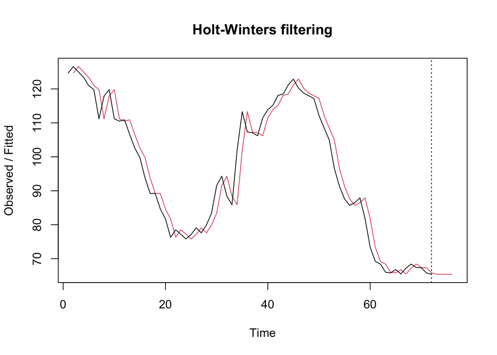

```r
# gfrsgEMA$SSE
gfrsgPredict <- predict(gfrsgEMA, n.ahead = 4)
plot(gfrsgEMA, gfrsgPredict)
```

```r
gfrsgPredict[1]
```

```
## [1] 65.40002
```

##### Root Mean Squared Error

```r
err <- as.numeric(gfrsgPredict[1:4] -
                    gfrsg[(length(gfrsg)-3):length(gfrsg)])
rmse <- sqrt(mean(err^2))
rmse
```

```
## [1] 1.393722
```

### Data Mining / Optimal Model Selection

#### Linear Hypothesis

- p-value of the F-statistic is small < 0.05, providing sufficient evidence to reject the null hypothesis that the unrestricted model is not significantly better than the restricted one in terms of explanatory power for Y

```r
linMod <- lm(durat ~ tserved + drugs + alcohol + priors + workprg, data = recid)
linearHypothesis(linMod,
                                 c("drugs=0", "priors=0")) # restricted model
```

```
## Linear hypothesis test
##
## Hypothesis:
## drugs = 0
## priors = 0
##
## Model 1: restricted model
## Model 2: durat ~ tserved + drugs + alcohol + priors + workprg
##
##   Res.Df     RSS Df Sum of Sq      F    Pr(>F)
## 1   1441 1022808
## 2   1439 1011922  2     10886 7.7406 0.0004532 ***
## ---
## Signif. codes:  0 '***' 0.001 '**' 0.01 '*' 0.05 '.' 0.1 ' ' 1
```

#### K-means clustering

- If the variables are on very different scales, need to standardise first (to mean 0, sd 1)
- There is a clear elbow at n = 2 clusters
- There are n clusters, with different preferences
  - Cluster 1 will have more (), more (), less (), …

```r
kmeans(mtcars, centers = 3, nstart=10)
```

```
## K-means clustering with 3 clusters of sizes 7, 9, 16
##
## Cluster means:
##        mpg      cyl     disp       hp     drat       wt     qsec        vs
## 1 17.01429 7.428571 276.0571 150.7143 2.994286 3.601429 18.11857 0.2857143
## 2 14.64444 8.000000 388.2222 232.1111 3.343333 4.161556 16.40444 0.0000000
## 3 24.50000 4.625000 122.2937  96.8750 4.002500 2.518000 18.54312 0.7500000
##          am     gear     carb
## 1 0.0000000 3.000000 2.142857
## 2 0.2222222 3.444444 4.000000
## 3 0.6875000 4.125000 2.437500
##
## Clustering vector:
##           Mazda RX4       Mazda RX4 Wag          Datsun 710      Hornet 4 Drive
##                   3                   3                   3                   1
##   Hornet Sportabout             Valiant          Duster 360           Merc 240D
##                   2                   1                   2                   3
##            Merc 230            Merc 280           Merc 280C          Merc 450SE
##                   3                   3                   3                   1
##          Merc 450SL         Merc 450SLC  Cadillac Fleetwood Lincoln Continental
##                   1                   1                   2                   2
##   Chrysler Imperial            Fiat 128         Honda Civic      Toyota Corolla
##                   2                   3                   3                   3
##       Toyota Corona    Dodge Challenger         AMC Javelin          Camaro Z28
##                   3                   1                   1                   2
##    Pontiac Firebird           Fiat X1-9       Porsche 914-2        Lotus Europa
##                   2                   3                   3                   3
##      Ford Pantera L        Ferrari Dino       Maserati Bora          Volvo 142E
##                   2                   3                   2                   3
##
## Within cluster sum of squares by cluster:
## [1] 11846.09 46659.32 32838.00
##  (between_SS / total_SS =  85.3 %)
##
## Available components:
##
## [1] "cluster"      "centers"      "totss"        "withinss"     "tot.withinss"
## [6] "betweenss"    "size"         "iter"         "ifault"
```

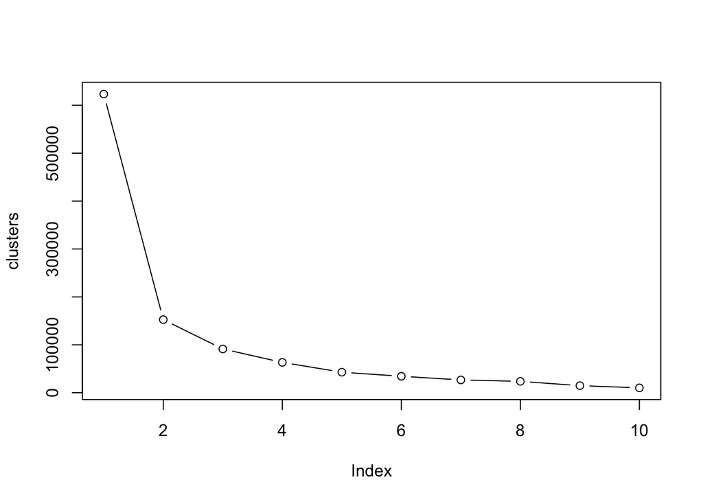

```r
clusters <- rep(NA, 10)
for (k in c(1:10)) {
    clusters[k] = kmeans(mtcars, k, nstart=10)$tot.withinss
}
plot(clusters, type="b")
```

```r
kmeans_opt <- kmeans(mtcars, 2, nstart=10)
kmeans_opt$centers
```

```
##        mpg      cyl     disp        hp     drat       wt     qsec        vs
## 1 23.97222 4.777778 135.5389  98.05556 3.882222 2.609056 18.68611 0.7777778
## 2 15.10000 8.000000 353.1000 209.21429 3.229286 3.999214 16.77214 0.0000000
##          am     gear     carb
## 1 0.6111111 4.000000 2.277778
## 2 0.1428571 3.285714 3.500000
```

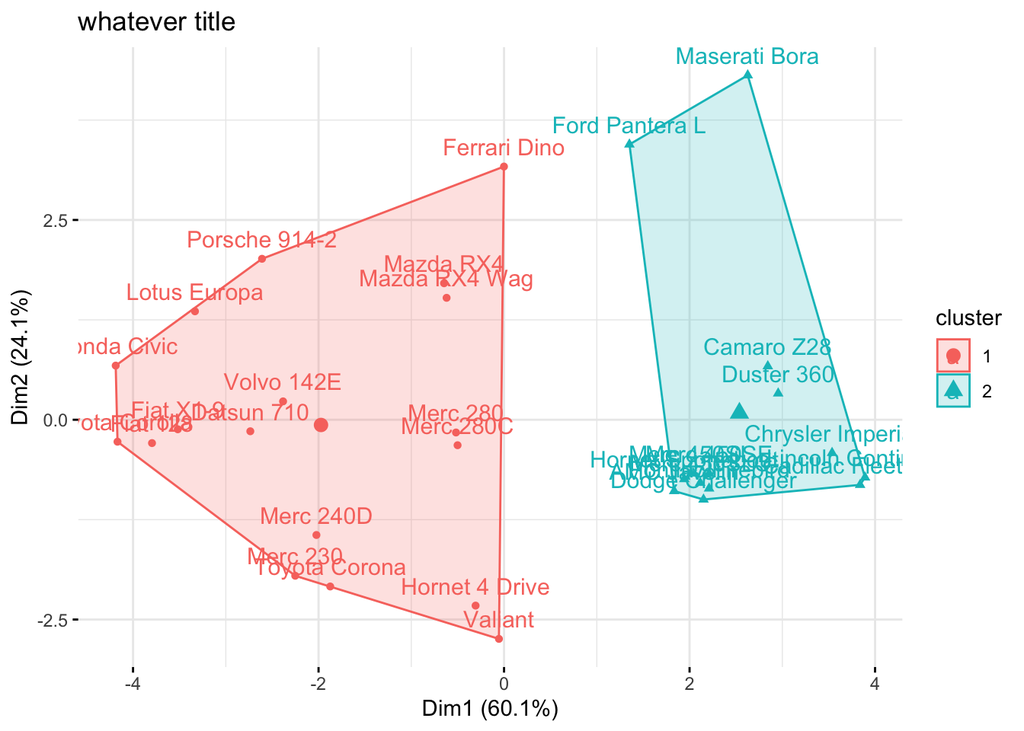

```r
# To plot the clusters for the specific kmeans()
fviz_cluster(kmeans_opt,
                         data = mtcars,
                         ggtheme = theme_minimal(),
                         main = "whatever title")
```

#### Stepwise Regression

##### Backward Stepwise Regression

```r
linMod <- lm(colgpa ~ . - colgpa, data = gpa2)
step(linMod, direction = "backward")
```

```
## Start:  AIC=-5003
## colgpa ~ (sat + tothrs + athlete + verbmath + hsize + hsrank +
##     hsperc + female + white + black + hsizesq) - colgpa
##
...
```

```
##
## Call:
## lm(formula = colgpa ~ sat + tothrs + athlete + hsrank + hsperc +
##     female + black + hsizesq, data = gpa2)
...
```

##### Forward Stepwise Regression

```r
linMod <- lm(colgpa ~ . - colgpa, data = gpa2)
kitSink <- lm(colgpa ~ 1, data = gpa2)
step(kitSink, scope = formula(linMod), direction = "forward")
```

```
## Start:  AIC=-3454.11
## colgpa ~ 1
##
##            Df Sum of Sq    RSS     AIC
...
```

```
##
## Call:
## lm(formula = colgpa ~ hsperc + sat + female + tothrs + black +
##     hsrank + athlete + hsizesq, data = gpa2)
...
```

```r
# step(kitSink, scope = colgpa ~ . - colgpa, direction = "forward")
```

#### Principle Component Analysis (PCA)

```r
gpa2Num <- gpa2 %>% select(-colgpa, -athlete, -female, -white, -black)
gpa2pca <- prcomp(gpa2Num,
                  center = TRUE,
                  scale = TRUE) # scale = TRUE standardises the predictors, making them comparable
summary(gpa2pca)
```

```
## Importance of components:
##                           PC1    PC2    PC3    PC4    PC5     PC6     PC7
## Standard deviation     1.5987 1.2252 1.0065 0.9872 0.8736 0.38518 0.20951
## Proportion of Variance 0.3651 0.2145 0.1447 0.1392 0.1090 0.02119 0.00627
## Cumulative Proportion  0.3651 0.5796 0.7243 0.8635 0.9725 0.99373 1.00000
```

```r
# Load all PC into the df
gpa2$pc1 <- gpa2pca$x[,"PC1"]
gpa2$pc2 <- gpa2pca$x[,"PC2"]
gpa2$pc3 <- gpa2pca$x[,"PC3"]
gpa2$pc4 <- gpa2pca$x[,"PC4"]
gpa2$pc5 <- gpa2pca$x[,"PC5"]

gpa2pca$rotation
```

```
##                  PC1         PC2         PC3          PC4         PC5
## sat       0.06656798  0.53421649 -0.14991876  0.245185903  0.79211592
## tothrs    0.07999804  0.12440791  0.71511119 -0.638687977  0.24239915
## verbmath  0.05309449 -0.08610886  0.67532220  0.729186558 -0.04435742
## hsize    -0.55674951  0.32517516  0.06420890  0.012287478 -0.15775805
## hsrank   -0.54893054 -0.26805419  0.02426740 -0.005839207  0.22231572
## hsperc   -0.23246662 -0.65891060 -0.02312981 -0.007162500  0.46970974
## hsizesq  -0.56658142  0.28278184  0.06952417  0.003482020 -0.12995508
##                   PC6          PC7
## sat      -0.010706836  0.005236825
## tothrs   -0.004229009 -0.006435243
## verbmath -0.004778647  0.001648602
## hsize     0.113973730 -0.736301375
## hsrank   -0.747289611  0.135399996
## hsperc    0.521277349 -0.137304375
## hsizesq   0.395831775  0.648539189
```

```r
# Check if result is correct
sum(gpa2pca$rotation[,1]^2) # Orthonormal
```

```
## [1] 1
```

#### Confusion / Classfication Matrix

##### Table

```r
# predictions is your variable from predict(...)
gpa2$pred_scholarship <- ifelse(predictions >= 0.5, 1, 0)

# Confusion Matrix with caret
# confusionMatrix(data = as.factor(gpa2$pred_scholarship),
#                 reference = as.factor(gpa2$scholarship))

# Base R
tbl <- table(gpa2$pred_scholarship, # Rows
             gpa2$scholarship) # Columns
dimnames(tbl) <- list(Predicted = c("No Scholarship", "Scholarship"),
                      Actual = c("No Scholarship", "Scholarship"))
tbl
```

```
##                 Actual
## Predicted        No Scholarship Scholarship
##   No Scholarship           3199         562
##   Scholarship               125         251
```

##### Statistics

```r
# Sensitivity :
TP <- tbl[2,2]
TN <- tbl[1,1]
FP <- tbl[2,1]
FN <- tbl[1,2]
```

###### Classification Accuracy

```r
# Classification Accuracy
(TP+TN)/(TP+TN+FP+FN)
```

```
## [1] 0.8339376
```

###### Sensitivity

```r
# Sensitivity
TP/(TP+FN)
```

```
## [1] 0.3087331
```

###### Precision

```r
# Precision
TP/(TP+FP)
```

```
## [1] 0.6675532
```

###### Specificity

```r
# Specificity
TN/(TN+FP)
```

```
## [1] 0.9623947
```

## Prescriptive Analytics

### Linear Optimisation

#### Table

##### 2 Variables

Let $X_1$ be …, $X_2$ be …

| Maximize total daily profit using decision variables $X_1$, $X_2$ | Profit = 6000 $X_1$ + 15000 $X_2$ |
| --- | --- |
| Subject to |  |
| Labor Time Constraint | 0.5$X_1$ + 2$X_2$ $\leq$ 72 |
| Machine Time Constraint | 2$X_1$ + 1.5$X_2$ $\leq$ 48 |
| Non-Negativity Constraint 1 | $X_1$ + $\quad$ $\geq$ 0 |
| Non-Negativity Constraint 2 | $\quad$ + $X_2$ $\geq$ 0 |

##### 3 Variables

Let $X_1$ be …, $X_2$ be … and $X_3$ be …

| Maximize total daily profit using decision variables $X_1$, $X_2$, $X_3$ | Profit = 6000 $X_1$ + 15000 $X_2$ + 23000 $X_3$ |
| --- | --- |
| Subject to |  |
| Labor Time Constraint | 0.5$X_1$ + 2$X_2$ + 4$X_3$ $\leq$ 72 |
| Machine Time Constraint | 2$X_1$ + 1.5$X_2$ + 1$X_3$ $\leq$ 48 |
| Non-Negativity Constraint 1 | $X_1$ + $\quad$ + $\quad$ $\geq$ 0 |
| Non-Negativity Constraint 2 | $\quad$ + $X_2$ + $\quad$ $\geq$ 0 |
| Non-Negativity Constraint 3 | $\quad$ + $\quad$ + $X_3$ $\geq$ 0 |

##### 4 Variables

Let $X_1$ be …, $X_2$ be … and $X_3$ be … and $X_4$ be …

| Maximize total daily profit using decision variables $X_1$, $X_2$, $X_3$, $X_4$ | Profit = 6000 $X_1$ + 15000 $X_2$ + 23000 $X_3$ + 5000$X_4$ |
| --- | --- |
| Subject to |  |
| Labor Time Constraint | 0.5$X_1$ + 2$X_2$ + 4$X_3$ + 5$X_4$ $\leq$ 72 |
| Machine Time Constraint | 2$X_1$ + 1.5$X_2$ + 1$X_3$ + 4$X_4$ $\leq$ 48 |
| Non-Negativity Constraint 1 | $X_1$ + $\quad$ + $\quad$ + $\quad$ $\geq$ 0 |
| Non-Negativity Constraint 2 | $\quad$ + $X_2$ + $\quad$ + $\quad$ $\geq$ 0 |
| Non-Negativity Constraint 3 | $\quad$ + $\quad$ + $X_3$ + $\quad$ $\geq$ 0 |
| Non-Negativity Constraint 4 | $\quad$ + $\quad$ + $\quad$ + $X_4$ $\geq$ 0 |
| Binary, Integer, Non-Negativity Constraints | $X_1$ to $X_4$ all binary, integers and ≥0 |

#### lpSolve

##### Function

```r
obj.fn <- c(6000, 15000, 23000)
const.mat <- matrix(c(0.5, 2, 4, 2, 1.5, 1), ncol = 3, byrow = TRUE)
const.dir <- c("<=", "<=")
const.rhs <- c(72, 48)

#lp() to find output - change to min when finding minimum output
lp.solution <- lpSolve::lp("max", obj.fn, const.mat, const.dir, const.rhs,
                           # int.vec = c(1, 2, 3), # For Integer Optimisation
                           compute.sens = TRUE
                           )

lp.solution # Optimal solution output
```

```
## Success: the objective function is 519000
```

```r
lp.solution$solution # Optimal solution inputs
```

```
## [1]  0 30  3
```

##### Sensitivity Analysis (Upper / Lower Bound)

- If the () is in the range of (-$\infty$, 500), it is optimal to …

```r
# Inclusive of upper and lower bound
cbind(lp.solution$sens.coef.from, lp.solution$sens.coef.to)
```

```
##               [,1]     [,2]
## [1,] -1.000000e+30  9437.50
## [2,]  1.316667e+04 34500.00
## [3,]  1.000000e+04 27230.77
```

##### Shadow Prices / Duals

- The breakeven price of one additional () is ().
- It is not possible for () to prepare more (x) without reducing his optimal () as he has already (). If he were to produce more (x) by taking () that were supposed to be used for (y), he would no longer achieve the optimal (). If he wanted to prepare more (), he would either have to increase the amount of () he can acquire, or raise the profit gained from () to at least (coeff.to) which means pricing the () to at least ().

```r
lp.solution$duals
```

```
## [1]  4875.0  3500.0 -3437.5     0.0     0.0
```

| Logical Statements | Constraint |
| --- | --- |
| If A, then B | B $\ge$ A |
| If not A, then B | B $\ge$ (1-A) |
| If A, then not B | (1-B) $\ge$ A |
| If A, then B and C | (B+C) $\ge$ 2A |
| If A and B, then C | (A+B-C) $\le$ 1 |
| If A or B, then C | C $\ge$ (A+B) |

NOTE: For If (A and B, then C), C can be True without A and B being True as well!!